# Capstone Project

## Google Data Analytics Capstone Project

[figure not shown]

*Scenario*: You are a junior data analyst working in the marketing analyst team at Cyclistic, a bike-share company in Chicago. The director of marketing believes the company’s future success depends on maximizing the number of annual memberships. Therefore, your team wants to understand how casual riders and annual members use Cyclistic bikes differently. From these insights, your team will design a new marketing strategy to convert casual riders into annual members. But first, Cyclistic executives must approve your recommendations, so they must be backed up with compelling data insights and professional data visualizations.

# *—- ASK —-* :

- The Cyclistic team wants to convert casual riders into annual pass members. In order to do that we must first find out what makes the casual riders different from the annual riders and what the casual riders need in order to convert into annual members.

- The insights we find can be used by the marketing team to create a campaign that can hopefully covert the casual members into annual members

# *—- PREPARE —-*:

Where is your data located?.

- The data is located in Kaggle and [in this online link provided by Google](https://divvy-tripdata.s3.amazonaws.com/index.html)

How is the data organized?.

- The dataset is comprised of many CSV files each one pertaining to a specific month from 2020/04 to 2022/04

Are there issues with bias or credibility in this data? Does your data ROCCC?.

- This data appears bias free and follows the ROCCC rules.

How are you addressing licensing, privacy, security, and accessibility?.

- This data is collected by the own company and does not contain any personal information about the customers.

How did you verify the data’s integrity?.

- Looking at the data through Excel, it does look like all of the spreadsheets contain the same variables and is accurate, complete and consistent

How does it help you answer your question?.

- The data contained within can help us find some differences between the Casual and Annual Pass riders

Are there any problems with the data?.

- It would help if we had a bit more information about the customers such as Gender and Occupation

# *—- PROCESS —-*:

What tools are you choosing and why?.

- I’m using R as the for the flexibility of both being able to clean the data and also analyze it at the same time.

Have you ensured your data’s integrity?.

- Yes, I have ensured the data’s integrity

Let’s start by importing the libraries we will be using:

```r
library(tidyverse)
library(janitor)
library(lubridate)
library(skimr)
library(data.table)
library(ggplot2)
```

Now let’s import our CSVs. We will be using the fread() function from the data.table package as the data is quite large and fread() is much faster than the normal read_csv().

```r
csv_202004 <- fread("202004-divvy-tripdata.csv")
csv_202005 <- fread("202005-divvy-tripdata.csv")
csv_202006 <- fread("202006-divvy-tripdata.csv")
csv_202007 <- fread("202007-divvy-tripdata.csv")
csv_202008 <- fread("202008-divvy-tripdata.csv")
csv_202009 <- fread("202009-divvy-tripdata.csv")
csv_202010 <- fread("202010-divvy-tripdata.csv")
csv_202011 <- fread("202011-divvy-tripdata.csv")
csv_202012 <- fread("202012-divvy-tripdata.csv")
csv_202101 <- fread("202101-divvy-tripdata.csv")
csv_202102 <- fread("202102-divvy-tripdata.csv")
csv_202103 <- fread("202103-divvy-tripdata.csv")
csv_202104 <- fread("202104-divvy-tripdata.csv")
csv_202105 <- fread("202105-divvy-tripdata.csv")
csv_202106 <- fread("202106-divvy-tripdata.csv")
csv_202107 <- fread("202107-divvy-tripdata.csv")
csv_202108 <- fread("202108-divvy-tripdata.csv")
csv_202109 <- fread("202109-divvy-tripdata.csv")
csv_202110 <- fread("202110-divvy-tripdata.csv")
csv_202111 <- fread("202111-divvy-tripdata.csv")
csv_202112 <- fread("202112-divvy-tripdata.csv")
csv_202201 <- fread("202201-divvy-tripdata.csv")
csv_202202 <- fread("202202-divvy-tripdata.csv")
csv_202203 <- fread("202203-divvy-tripdata.csv")
csv_202204 <- fread("202204-divvy-tripdata.csv")
```

Now let’s check to see if the columns are the same type so we can join them all into one big dataset

```r
#| label: compare-columns
#| include: true

compare_df_cols_same(
  csv_202004,csv_202005,csv_202006,csv_202007,csv_202008,csv_202009,csv_202010,csv_202011,csv_202012,csv_202101,csv_202102,csv_202103,csv_202104,csv_202105,csv_202106,csv_202107,csv_202108,csv_202109,csv_202110,csv_202111,csv_202112,csv_202201,csv_202202,csv_202203,csv_202204,
  bind_method = c("bind_rows", "rbind"),
  verbose = TRUE
)
```

```
       column_name     ..1     ..2     ..3     ..4     ..5     ..6     ..7
1   end_station_id integer integer integer integer integer integer integer
2 start_station_id integer integer integer integer integer integer integer
      ..8       ..9      ..10      ..11      ..12      ..13      ..14      ..15
1 integer character character character character character character character
2 integer character character character character character character character
       ..16      ..17      ..18      ..19      ..20      ..21      ..22
1 character character character character character character character
2 character character character character character character character
       ..23      ..24      ..25
1 character character character
2 character character character
```

```
[1] FALSE
```

So let’s turn all the Integer type columns into Character type

```r
csv_202004_2 <- mutate(csv_202004,start_station_id = as.character(start_station_id),
                     end_station_id = as.character   (end_station_id))
csv_202005_2 <- mutate(csv_202005,start_station_id = as.character(start_station_id),
                     end_station_id = as.character(end_station_id))
csv_202006_2 <- mutate(csv_202006,start_station_id = as.character(start_station_id),
                     end_station_id = as.character(end_station_id))
csv_202007_2 <- mutate(csv_202007,start_station_id = as.character(start_station_id),
                     end_station_id = as.character(end_station_id))
csv_202008_2 <- mutate(csv_202008,start_station_id = as.character(start_station_id),
                     end_station_id = as.character(end_station_id))
csv_202009_2 <- mutate(csv_202009,start_station_id = as.character(start_station_id),
                     end_station_id = as.character(end_station_id))
csv_202010_2 <- mutate(csv_202010,start_station_id = as.character(start_station_id),
                     end_station_id = as.character(end_station_id))
csv_202011_2 <- mutate(csv_202011,start_station_id = as.character(start_station_id),
                     end_station_id = as.character(end_station_id))
```

Now let’s create merge all these dataframes into a single one:

```r
merged_df <- bind_rows(csv_202004_2,csv_202005_2,csv_202006_2,csv_202007_2,csv_202008_2,csv_202009_2,csv_202010_2,csv_202011_2,csv_202012,csv_202101,csv_202102,csv_202103,csv_202104,csv_202105,csv_202106,csv_202107,csv_202108,csv_202109,csv_202110,csv_202111,csv_202112,csv_202201,csv_202202,csv_202203,csv_202204)
```

```r
skim_without_charts(merged_df)
```

Data summary

| Name | merged_df |
| --- | --- |
| Number of rows | 9584529 |
| Number of columns | 13 |
| Key | NULL |
| _______________________ |  |
| Column type frequency: |  |
| character | 7 |
| numeric | 4 |
| POSIXct | 2 |
| ________________________ |  |
| Group variables | None |

**Variable type: character**

| skim_variable | n_missing | complete_rate | min | max | empty | n_unique | whitespace |
| --- | --- | --- | --- | --- | --- | --- | --- |
| ride_id | 0 | 1.00 | 16 | 16 | 0 | 9584320 | 0 |
| rideable_type | 0 | 1.00 | 11 | 13 | 0 | 3 | 0 |
| start_station_name | 0 | 1.00 | 0 | 53 | 938438 | 894 | 0 |
| start_station_id | 83583 | 0.99 | 0 | 44 | 855478 | 1322 | 0 |
| end_station_name | 0 | 1.00 | 0 | 53 | 1014777 | 893 | 0 |
| end_station_id | 98104 | 0.99 | 0 | 44 | 917134 | 1322 | 0 |
| member_casual | 0 | 1.00 | 6 | 6 | 0 | 2 | 0 |

**Variable type: numeric**

| skim_variable | n_missing | complete_rate | mean | sd | p0 | p25 | p50 | p75 | p100 |
| --- | --- | --- | --- | --- | --- | --- | --- | --- | --- |
| start_lat | 0 | 1 | 41.90 | 0.05 | 41.64 | 41.88 | 41.90 | 41.93 | 45.64 |
| start_lng | 0 | 1 | -87.65 | 0.03 | -87.87 | -87.66 | -87.64 | -87.63 | -73.80 |
| end_lat | 9771 | 1 | 41.90 | 0.05 | 41.39 | 41.88 | 41.90 | 41.93 | 42.17 |
| end_lng | 9771 | 1 | -87.65 | 0.03 | -88.97 | -87.66 | -87.64 | -87.63 | -87.44 |

**Variable type: POSIXct**

| skim_variable | n_missing | complete_rate | min | max | median | n_unique |
| --- | --- | --- | --- | --- | --- | --- |
| started_at | 0 | 1 | 2020-04-01 00:00:30 | 2022-04-30 23:59:54 | 2021-06-17 17:42:23 | 8160044 |
| ended_at | 0 | 1 | 2020-04-01 00:10:45 | 2022-05-02 00:35:01 | 2021-06-17 18:02:36 | 8142235 |

However, before we do that, we notice that some of the columns that might appear not so useful such as latitude and longitude columns, but we also want to make a dashboard later using Tableau so these coordinates might come in useful when displaying maps so we chose to keep it. If we were not planning on using another data viz software later we could drop it by using the following code:

```r
#merged_df_2 <- merged_df %>%
#  select(-c(start_lat,start_lng,end_lat, end_lng))
#glimpse(merged_df_2)
```

Now let’s check for duplicate rows

```r
summary(merged_df)
```

```
   ride_id          rideable_type        started_at
 Length:9584529     Length:9584529     Min.   :2020-04-01 00:00:30.00
 Class :character   Class :character   1st Qu.:2020-10-05 17:02:01.00
 Mode  :character   Mode  :character   Median :2021-06-17 17:42:23.00
                                       Mean   :2021-04-30 05:09:13.78
                                       3rd Qu.:2021-09-18 21:43:14.00
                                       Max.   :2022-04-30 23:59:54.00

    ended_at                      start_station_name start_station_id
 Min.   :2020-04-01 00:10:45.00   Length:9584529     Length:9584529
 1st Qu.:2020-10-05 17:18:43.00   Class :character   Class :character
 Median :2021-06-17 18:02:36.00   Mode  :character   Mode  :character
 Mean   :2021-04-30 05:31:47.69
 3rd Qu.:2021-09-18 22:08:39.00
 Max.   :2022-05-02 00:35:01.00

 end_station_name   end_station_id       start_lat       start_lng
 Length:9584529     Length:9584529     Min.   :41.64   Min.   :-87.87
 Class :character   Class :character   1st Qu.:41.88   1st Qu.:-87.66
 Mode  :character   Mode  :character   Median :41.90   Median :-87.64
                                       Mean   :41.90   Mean   :-87.65
                                       3rd Qu.:41.93   3rd Qu.:-87.63
                                       Max.   :45.64   Max.   :-73.80

    end_lat         end_lng       member_casual
 Min.   :41.39   Min.   :-88.97   Length:9584529
 1st Qu.:41.88   1st Qu.:-87.66   Class :character
 Median :41.90   Median :-87.64   Mode  :character
 Mean   :41.90   Mean   :-87.65
 3rd Qu.:41.93   3rd Qu.:-87.63
 Max.   :42.17   Max.   :-87.44
 NA's   :9771    NA's   :9771
```

```r
summary(distinct(merged_df))
```

```
   ride_id          rideable_type        started_at
 Length:9584529     Length:9584529     Min.   :2020-04-01 00:00:30.00
 Class :character   Class :character   1st Qu.:2020-10-05 17:02:01.00
 Mode  :character   Mode  :character   Median :2021-06-17 17:42:23.00
                                       Mean   :2021-04-30 05:09:13.78
                                       3rd Qu.:2021-09-18 21:43:14.00
                                       Max.   :2022-04-30 23:59:54.00

    ended_at                      start_station_name start_station_id
 Min.   :2020-04-01 00:10:45.00   Length:9584529     Length:9584529
 1st Qu.:2020-10-05 17:18:43.00   Class :character   Class :character
 Median :2021-06-17 18:02:36.00   Mode  :character   Mode  :character
 Mean   :2021-04-30 05:31:47.69
 3rd Qu.:2021-09-18 22:08:39.00
 Max.   :2022-05-02 00:35:01.00

 end_station_name   end_station_id       start_lat       start_lng
 Length:9584529     Length:9584529     Min.   :41.64   Min.   :-87.87
 Class :character   Class :character   1st Qu.:41.88   1st Qu.:-87.66
 Mode  :character   Mode  :character   Median :41.90   Median :-87.64
                                       Mean   :41.90   Mean   :-87.65
                                       3rd Qu.:41.93   3rd Qu.:-87.63
                                       Max.   :45.64   Max.   :-73.80

    end_lat         end_lng       member_casual
 Min.   :41.39   Min.   :-88.97   Length:9584529
 1st Qu.:41.88   1st Qu.:-87.66   Class :character
 Median :41.90   Median :-87.64   Mode  :character
 Mean   :41.90   Mean   :-87.65
 3rd Qu.:41.93   3rd Qu.:-87.63
 Max.   :42.17   Max.   :-87.44
 NA's   :9771    NA's   :9771
```

We can see that both the length for the normal and distinct values of the dataframe are the same so that means that there are no duplicated rows

```r
# Now let's drop the NAs

merged_df_clean <- drop_na(merged_df)
skim_without_charts(merged_df_clean)
```

Data summary

| Name | merged_df_clean |
| --- | --- |
| Number of rows | 9444262 |
| Number of columns | 13 |
| Key | NULL |
| _______________________ |  |
| Column type frequency: |  |
| character | 7 |
| numeric | 4 |
| POSIXct | 2 |
| ________________________ |  |
| Group variables | None |

**Variable type: character**

| skim_variable | n_missing | complete_rate | min | max | empty | n_unique | whitespace |
| --- | --- | --- | --- | --- | --- | --- | --- |
| ride_id | 0 | 1 | 16 | 16 | 0 | 9444054 | 0 |
| rideable_type | 0 | 1 | 11 | 13 | 0 | 3 | 0 |
| start_station_name | 0 | 1 | 0 | 53 | 855481 | 893 | 0 |
| start_station_id | 0 | 1 | 0 | 44 | 855478 | 1322 | 0 |
| end_station_name | 0 | 1 | 0 | 53 | 911506 | 892 | 0 |
| end_station_id | 0 | 1 | 0 | 44 | 911506 | 1322 | 0 |
| member_casual | 0 | 1 | 6 | 6 | 0 | 2 | 0 |

**Variable type: numeric**

| skim_variable | n_missing | complete_rate | mean | sd | p0 | p25 | p50 | p75 | p100 |
| --- | --- | --- | --- | --- | --- | --- | --- | --- | --- |
| start_lat | 0 | 1 | 41.90 | 0.05 | 41.64 | 41.88 | 41.90 | 41.93 | 45.64 |
| start_lng | 0 | 1 | -87.65 | 0.03 | -87.84 | -87.66 | -87.64 | -87.63 | -73.80 |
| end_lat | 0 | 1 | 41.90 | 0.05 | 41.39 | 41.88 | 41.90 | 41.93 | 42.17 |
| end_lng | 0 | 1 | -87.65 | 0.03 | -88.97 | -87.66 | -87.64 | -87.63 | -87.49 |

**Variable type: POSIXct**

| skim_variable | n_missing | complete_rate | min | max | median | n_unique |
| --- | --- | --- | --- | --- | --- | --- |
| started_at | 0 | 1 | 2020-04-01 00:00:30 | 2022-04-30 23:59:54 | 2021-06-19 18:26:48 | 8051022 |
| ended_at | 0 | 1 | 2020-04-01 00:10:45 | 2022-05-01 16:16:59 | 2021-06-19 18:53:12 | 8032955 |

We dropped the NAs but there there are still some rows in the “start_station_name”and “end_station_name” columns that are blank. There are quite a lot of them so ideally we would ask the Cyclist team about it however we cannot do that here. So instead I will leave these columns as is since the data about members/casuals and ride times will still be useful for us. When we analyze the station data more carefully we will deal with them.

Now let’s create some other columns that could be useful for our analysis

```r
# First we convert the dates from the started_at and ended_at columns into POSIXct datetime values

merged_df_clean$started_at <- as.POSIXct(merged_df_clean$started_at, "%Y-%m-%d %H:%M:%S")
merged_df_clean$ended_at <- as.POSIXct(merged_df_clean$ended_at, "%Y-%m-%d %H:%M:%S")


#Then we separate the dates into month, day, year and weekday and add the starting hour of the ride

merged_df_clean$date <- as.Date(merged_df_clean$started_at)
merged_df_clean$month <- format(as.Date(merged_df_clean$started_at),"%B")
merged_df_clean$day <- format(as.Date(merged_df_clean$date), "%d")
merged_df_clean$year <- format(as.Date(merged_df_clean$date), "%Y")
merged_df_clean$day_of_week <- format(as.Date(merged_df_clean$date), "%A")
merged_df_clean$start_hour <- as.numeric(format(merged_df_clean$started_at, '%H'))

# Change the month column to show the month names instead of numbers and order them for future graphs
# Order the day of the week columns for future graphs
merged_df_clean$month <- ordered(merged_df_clean$month, levels=c("January", "February", "March", "April", "May", "June", "July", "August", "September","October", "November", "December"))

merged_df_clean$day_of_week <- ordered(merged_df_clean$day_of_week, levels=c("Sunday", "Monday", "Tuesday", "Wednesday", "Thursday", "Friday", "Saturday"))



head(merged_df_clean)
```

```
            ride_id rideable_type          started_at            ended_at
1: A847FADBBC638E45   docked_bike 2020-04-26 17:45:14 2020-04-26 18:12:03
2: 5405B80E996FF60D   docked_bike 2020-04-17 17:08:54 2020-04-17 17:17:03
3: 5DD24A79A4E006F4   docked_bike 2020-04-01 17:54:13 2020-04-01 18:08:36
4: 2A59BBDF5CDBA725   docked_bike 2020-04-07 12:50:19 2020-04-07 13:02:31
5: 27AD306C119C6158   docked_bike 2020-04-18 10:22:59 2020-04-18 11:15:54
6: 356216E875132F61   docked_bike 2020-04-30 17:55:47 2020-04-30 18:01:11
                    start_station_name start_station_id
1:                        Eckhart Park               86
2:           Drake Ave & Fullerton Ave              503
3:                McClurg Ct & Erie St              142
4:        California Ave & Division St              216
5:                Rush St & Hubbard St              125
6: Mies van der Rohe Way & Chicago Ave              173
              end_station_name end_station_id start_lat start_lng end_lat
1: Lincoln Ave & Diversey Pkwy            152   41.8964  -87.6610 41.9322
2:             Kosciuszko Park            499   41.9244  -87.7154 41.9306
3:  Indiana Ave & Roosevelt Rd            255   41.8945  -87.6179 41.8679
4:      Wood St & Augusta Blvd            657   41.9030  -87.6975 41.8992
5:  Sheridan Rd & Lawrence Ave            323   41.8902  -87.6262 41.9695
6:     Streeter Dr & Grand Ave             35   41.8969  -87.6217 41.8923
    end_lng member_casual       date month day year day_of_week start_hour
1: -87.6586        member 2020-04-26 April  26 2020      Sunday         17
2: -87.7238        member 2020-04-17 April  17 2020      Friday         17
3: -87.6230        member 2020-04-01 April  01 2020   Wednesday         17
4: -87.6722        member 2020-04-07 April  07 2020     Tuesday         12
5: -87.6547        casual 2020-04-18 April  18 2020    Saturday         10
6: -87.6120        member 2020-04-30 April  30 2020    Thursday         17
```

Now let’s create another new column showing the total ride duration in minutes as well as joining the “start station” with the “end station” variables into a new “route” column

```r
merged_df_clean_v2 <- merged_df_clean %>%  mutate(merged_df_clean, ride_duration = round(difftime(ended_at, started_at, units = "mins"), 0),
                      route = str_c(start_station_name, end_station_name, sep=" -- "))

head(merged_df_clean_v2)
```

```
            ride_id rideable_type          started_at            ended_at
1: A847FADBBC638E45   docked_bike 2020-04-26 17:45:14 2020-04-26 18:12:03
2: 5405B80E996FF60D   docked_bike 2020-04-17 17:08:54 2020-04-17 17:17:03
3: 5DD24A79A4E006F4   docked_bike 2020-04-01 17:54:13 2020-04-01 18:08:36
4: 2A59BBDF5CDBA725   docked_bike 2020-04-07 12:50:19 2020-04-07 13:02:31
5: 27AD306C119C6158   docked_bike 2020-04-18 10:22:59 2020-04-18 11:15:54
6: 356216E875132F61   docked_bike 2020-04-30 17:55:47 2020-04-30 18:01:11
                    start_station_name start_station_id
1:                        Eckhart Park               86
2:           Drake Ave & Fullerton Ave              503
3:                McClurg Ct & Erie St              142
4:        California Ave & Division St              216
5:                Rush St & Hubbard St              125
6: Mies van der Rohe Way & Chicago Ave              173
              end_station_name end_station_id start_lat start_lng end_lat
```

[output cut: 20 more lines]

```r
#Let's check our newly created column and see if everything is alright and we don't have any negative values

duration_check <- merged_df_clean_v2[with(merged_df_clean, order(ride_duration)) , ]

head(duration_check)
```

```
            ride_id rideable_type          started_at            ended_at
1: 3ED2B8BCE6A914EF electric_bike 2020-12-15 12:10:14 2020-11-25 08:00:16
2: 6DF34F98F5DB335F electric_bike 2020-12-15 11:35:39 2020-11-25 07:40:56
3: BE1F691E387D7072   docked_bike 2020-12-15 11:34:23 2020-11-25 08:00:15
4: 321F7AE3AEDBAA13   docked_bike 2020-12-15 12:12:43 2020-11-25 08:42:16
5: BB4697B59E3FF12A   docked_bike 2020-12-15 11:34:38 2020-11-25 08:09:43
6: 05498BABECEB55B0   docked_bike 2020-12-15 12:11:52 2020-11-25 08:51:27
          start_station_name start_station_id                end_station_name
1:     Wells St & Concord Ln     TA1308000050          Clark St & Schiller St
2: Sheffield Ave & Willow St     TA1306000032       Sheffield Ave & Willow St
3:  Kingsbury St & Kinzie St     KA1503000043            Canal St & Monroe St
4:     Dayton St & North Ave            13058    Sheffield Ave & Kingsbury St
5:  Clark St & 9th St (AMLI)           SL-009          Dearborn St & Adams St
6:   Clinton St & Madison St     TA1305000032 Cityfront Plaza Dr & Pioneer Ct
   end_station_id start_lat start_lng  end_lat   end_lng member_casual
```

[output cut: 20 more lines]

```r
# Let's also check our station names to see in there's anything wrong

unique(merged_df_clean_v2$start_station_name)
```

```
  [1] "Eckhart Park"
  [2] "Drake Ave & Fullerton Ave"
  [3] "McClurg Ct & Erie St"
  [4] "California Ave & Division St"
  [5] "Rush St & Hubbard St"
  [6] "Mies van der Rohe Way & Chicago Ave"
  [7] "Streeter Dr & Grand Ave"
  [8] "Ogden Ave & Roosevelt Rd"
  [9] "LaSalle Dr & Huron St"
 [10] "Kedzie Ave & Lake St"
 [11] "Central Park Ave & North Ave"
 [12] "Western Ave & Walton St"
 [13] "Wabash Ave & 9th St"
 [14] "Leavitt St & Archer Ave"
 [15] "Clark St & Lincoln Ave"
```

[output cut: 878 more lines]

We can see that there are numbers with negative ride durations as well as some testing stations that should be removed

```r
# Remove the testing stations as well as remove rides with negative or 0 min ride time

merged_df_clean_v2 <- merged_df_clean_v2[!(merged_df_clean_v2$start_station_name %ilike% "TEST" | merged_df_clean_v2$ride_duration<=0),]
```

```r
#Let's see if it worked

nrow(subset(merged_df_clean_v2,ride_duration <= 0))
```

```
[1] 0
```

```r
nrow(subset(merged_df_clean_v2, start_station_name %ilike% "TEST"))
```

```
[1] 0
```

```r
# Let's also rename the member_casual column into member_type for easier understanding

colnames(merged_df_clean_v2)[colnames(merged_df_clean_v2) == "member_casual"] <- "member_type"
colnames(merged_df_clean_v2)
```

```
 [1] "ride_id"            "rideable_type"      "started_at"
 [4] "ended_at"           "start_station_name" "start_station_id"
 [7] "end_station_name"   "end_station_id"     "start_lat"
[10] "start_lng"          "end_lat"            "end_lng"
[13] "member_type"        "date"               "month"
[16] "day"                "year"               "day_of_week"
[19] "start_hour"         "ride_duration"      "route"
```

```r
summary(merged_df_clean_v2)
```

```
   ride_id          rideable_type        started_at
 Length:9338025     Length:9338025     Min.   :2020-04-01 00:00:30.0
 Class :character   Class :character   1st Qu.:2020-10-07 12:49:55.0
 Mode  :character   Mode  :character   Median :2021-06-19 19:56:58.0
                                       Mean   :2021-05-03 03:32:15.7
                                       3rd Qu.:2021-09-20 06:24:05.0
                                       Max.   :2022-04-30 23:59:52.0

    ended_at                      start_station_name start_station_id
 Min.   :2020-04-01 00:10:45.00   Length:9338025     Length:9338025
 1st Qu.:2020-10-07 13:08:14.00   Class :character   Class :character
 Median :2021-06-19 20:26:10.00   Mode  :character   Mode  :character
 Mean   :2021-05-03 03:55:24.25
 3rd Qu.:2021-09-20 06:38:40.00
 Max.   :2022-05-01 16:16:59.00

 end_station_name   end_station_id       start_lat       start_lng
 Length:9338025     Length:9338025     Min.   :41.64   Min.   :-87.84
 Class :character   Class :character   1st Qu.:41.88   1st Qu.:-87.66
 Mode  :character   Mode  :character   Median :41.90   Median :-87.64
                                       Mean   :41.90   Mean   :-87.65
                                       3rd Qu.:41.93   3rd Qu.:-87.63
                                       Max.   :42.07   Max.   :-87.52

    end_lat         end_lng       member_type             date
 Min.   :41.39   Min.   :-88.97   Length:9338025     Min.   :2020-04-01
 1st Qu.:41.88   1st Qu.:-87.66   Class :character   1st Qu.:2020-10-07
 Median :41.90   Median :-87.64   Mode  :character   Median :2021-06-19
 Mean   :41.90   Mean   :-87.65                      Mean   :2021-05-02
 3rd Qu.:41.93   3rd Qu.:-87.63                      3rd Qu.:2021-09-20
 Max.   :42.17   Max.   :-87.49                      Max.   :2022-04-30

       month             day                year              day_of_week
 August   :1395055   Length:9338025     Length:9338025     Sunday   :1408252
 July     :1357773   Class :character   Class :character   Monday   :1167767
 September:1241482   Mode  :character   Mode  :character   Tuesday  :1221528
 June     :1060337                                         Wednesday:1261167
 October  : 957944                                         Thursday :1258814
 April    : 783443                                         Friday   :1349120
 (Other)  :2541991                                         Saturday :1671377
   start_hour    ride_duration        route
 Min.   : 0.00   Length:9338025    Length:9338025
 1st Qu.:11.00   Class :difftime   Class :character
 Median :15.00   Mode  :numeric    Mode  :character
 Mean   :14.25
 3rd Qu.:18.00
 Max.   :23.00
```

Now let’s save this cleaned database in a CSV file. Again the data.table package comes in handy as fwrite() is much faster than the usual write.csv()

```r
#fwrite(merged_df_clean_v2, "capstone_merged_data.csv")
```

The data looks clean and ready for analyzing. Let’s go to the next stage

What steps have you taken to ensure that your data is clean?.

- I have analyzed it thoroughly and used R to clean and organize the data

Have you documented your cleaning process so you can review and share those results?.

- Yes, the process is thoroughly documented above

# *—- ANALYZE —-*

Let’s start the analysis phase

```r
merged_df_clean_v2 <- fread("capstone_merged_data.csv")

# Change the month columns to show the month names instead of numbers
merged_df_clean_v2$month <- ordered(merged_df_clean_v2$month, levels=c("January", "February", "March", "April", "May", "June", "July", "August", "September","October", "November", "December"))

merged_df_clean_v2$day_of_week <- ordered(merged_df_clean_v2$day_of_week, levels=c("Sunday", "Monday", "Tuesday", "Wednesday", "Thursday", "Friday", "Saturday"))

head(merged_df_clean_v2)
```

```
            ride_id rideable_type          started_at            ended_at
1: A847FADBBC638E45   docked_bike 2020-04-26 17:45:14 2020-04-26 18:12:03
2: 5405B80E996FF60D   docked_bike 2020-04-17 17:08:54 2020-04-17 17:17:03
3: 5DD24A79A4E006F4   docked_bike 2020-04-01 17:54:13 2020-04-01 18:08:36
4: 2A59BBDF5CDBA725   docked_bike 2020-04-07 12:50:19 2020-04-07 13:02:31
5: 27AD306C119C6158   docked_bike 2020-04-18 10:22:59 2020-04-18 11:15:54
6: 356216E875132F61   docked_bike 2020-04-30 17:55:47 2020-04-30 18:01:11
                    start_station_name start_station_id
1:                        Eckhart Park               86
2:           Drake Ave & Fullerton Ave              503
3:                McClurg Ct & Erie St              142
4:        California Ave & Division St              216
5:                Rush St & Hubbard St              125
6: Mies van der Rohe Way & Chicago Ave              173
              end_station_name end_station_id start_lat start_lng end_lat
```

[output cut: 20 more lines]

Let’s start off by taking a look at the distribution of casual and annual members in this dataset

```r
# First let's make a plot calculating how many casuals and annual members total and then taking the percentage

member_plot <- merged_df_clean_v2 %>%
  group_by(member_type) %>%
  tally %>%
  mutate(percentage = round(n/sum(n)*100))
```

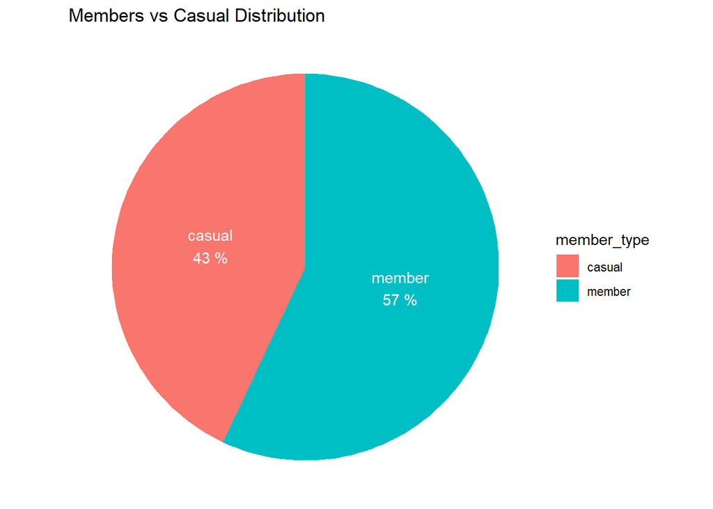

```r
# Now we plot

ggplot(member_plot, aes(x = 1, y = percentage, fill = member_type)) +
  geom_bar(stat = "identity", width =1) +
  geom_text(aes(label = paste(member_type, paste(percentage, "%"), sep = "\n")),
            position = position_stack(vjust = 0.5), color = "white") +
  labs(title = " Members vs Casual Distribution") +
  coord_polar(theta = "y") +
  theme_void()
```

We can see that there are more members than casuals represented in this dataset

Now let’s look at the monthly distribution of rides

```r
# First let's create a dataframe calculating the number of rides, average duration, and total duration per month to aid our visualizations

months_plot <- merged_df_clean_v2 %>%
  group_by(member_type, month) %>%
  summarize(
    number_of_rides = n(),
    average_duration = mean(ride_duration),
    total_duration = sum(ride_duration))
```

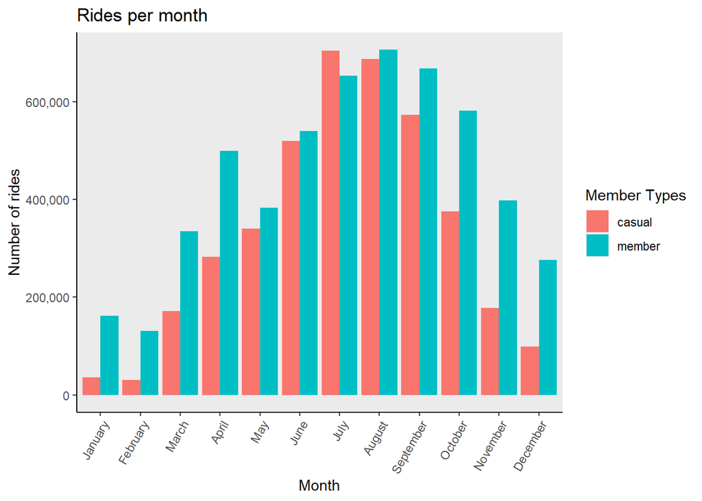

```r
# Now let's plot

ggplot(months_plot, aes(x = month, y = number_of_rides, fill = member_type)) +
  geom_col(position = "dodge") +
  theme(panel.border = element_blank(),
        panel.grid.major = element_blank(),
        panel.grid.minor = element_blank(),
        axis.line = element_line(colour = "black")
  ) +
  scale_y_continuous(labels = scales::comma) +
   theme(axis.text.x = element_text(angle = 60,hjust = 1)) +
  labs(
    title="Rides per month",
    x = "Month",
    y = "Number of rides",
    fill='Member Types'
    )
```

We can look online to see more clearly what the weather in Chicago is like

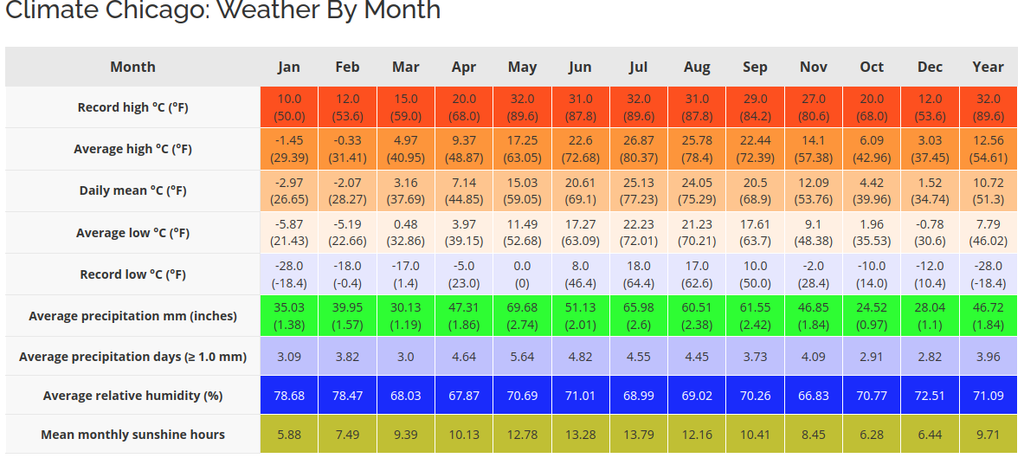

Looking at this chart we can see that indeed in the winter months the weather dips below 0º so it is no wonder the usage rate for the bikes dip as well.

Now let’s go a little deeper and look at the relationships betweek riders and days of the week

```r
# Once again create a database to help us visualize better our data

weekdays_plot <- merged_df_clean_v2 %>%
  group_by(member_type, day_of_week) %>%
  summarize(
    number_of_rides = n(),
    average_duration = mean(ride_duration),
    total_duration = sum(ride_duration))
```

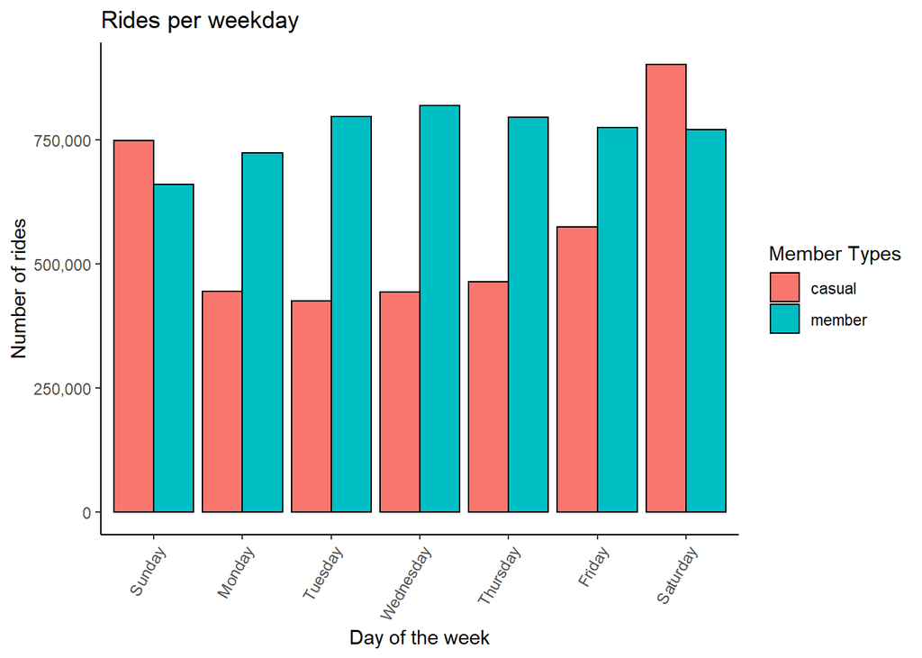

```r
# Now we plot

ggplot(weekdays_plot, aes(x = day_of_week, y = number_of_rides, fill = member_type)) +
  geom_col(position = "dodge", color="black") +
  theme(panel.border = element_blank(),
        panel.grid.major = element_blank(),
        panel.grid.minor = element_blank(),
        axis.line = element_line(colour = "black")
  ) +
    theme_classic() +
  scale_y_continuous(labels = scales::comma) +
   theme(axis.text.x = element_text(angle = 60,hjust = 1)) +
  labs(
    title="Rides per weekday",
    x = "Day of the week",
    y = "Number of rides",
    fill='Member Types'
    )
```

Now this is interesting! We can clearly see the spikes in the weekends for the casual members where they even surpass the annual pass members. This is probably because annual pass members use the bikes for getting to and from work everyday whilst the casual members use it more for fun or for a short trip to a store which means they use it more during the weekends when they have time.

Now let’s go even deeper and let’s look at the hourly distribution of the rides.

```r
# Create database

hourly_plot <- merged_df_clean_v2 %>%
  group_by(member_type, start_hour) %>%
  summarize(
    number_of_rides = n(),
    average_duration = mean(ride_duration),
    total_duration = sum(ride_duration))
```

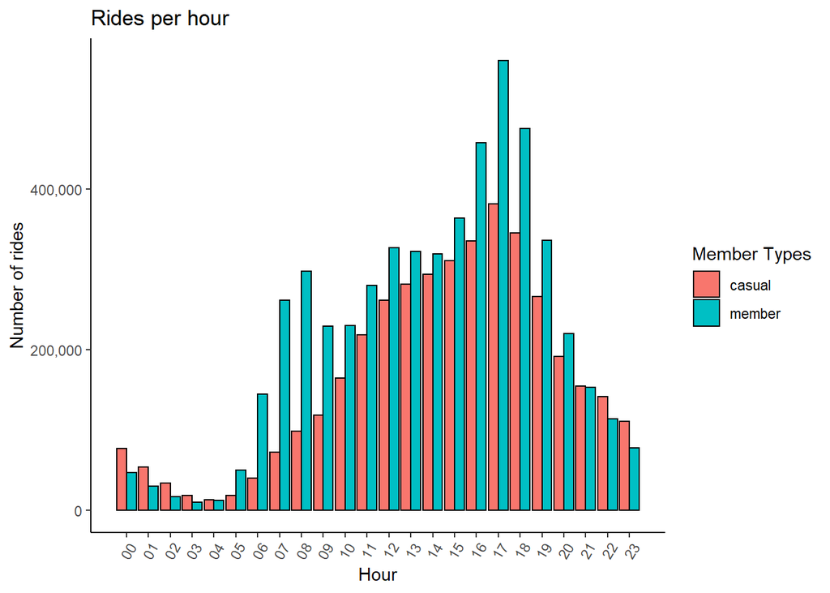

```r
# Plot it

ggplot(hourly_plot, aes(x = start_hour, y = number_of_rides, fill = member_type)) +
  geom_col(position = "dodge", color="black") +
  theme(panel.border = element_blank(),
        panel.grid.major = element_blank(),
        panel.grid.minor = element_blank(),
        axis.line = element_line(colour = "black")
  ) +
    theme_classic() +
  scale_y_continuous(labels = scales::comma) +
  scale_x_continuous(labels = formatC(0:23, width = 2, flag = "0"),breaks = 0:23) +
  theme(axis.text.x = element_text(angle = 60,hjust = 1)) +
  labs(
    title="Rides per hour",
    x = "Hour",
    y = "Number of rides",
    fill='Member Types'
    )
```

Here we can see that the number of rides slowly rise until hitting a peak at 17:00(5pm). We can see that in the morning the peak times are around 07-08:00 while in the afternoon the peak is between 16-18:00(4-6 pm)

Now let’s look at the average duration of trips by each hour

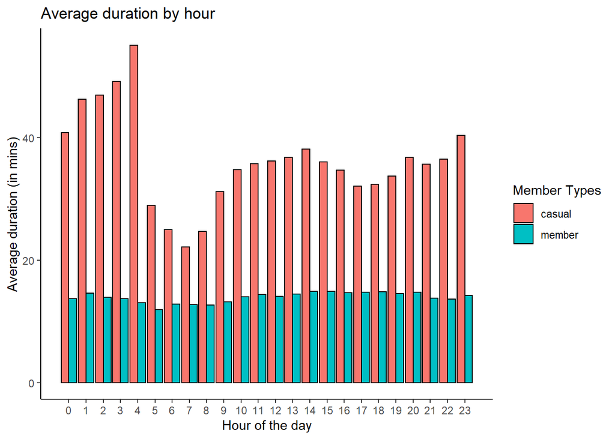

```r
# Plot it

ggplot(hourly_plot, aes(x = start_hour, y = average_duration, fill = member_type)) +
  geom_col(position = "dodge",color="black") +
  theme(panel.border = element_blank(),
        panel.grid.major = element_blank(),
        panel.grid.minor = element_blank(),
        axis.line = element_line(colour = "black")
  ) +
  theme_classic() +
   scale_y_continuous(labels = scales::comma) +
   scale_x_continuous(labels = formatC(0:23, width = 1, flag = "0"),breaks = 0:23) +
  labs(
    title="Average duration by hour",
    x = "Hour of the day",
    y = "Average duration (in mins)",
    fill='Member Types'
  )
```

Here we can see that the duration of rides by annual members is actually very consistent while the casual member’s average duration in less so. Interesting to note that the longest average duration for the casual type is during 04:00 in the morning. So while 04:00 is one of the times with the least amount of people riding, the people that do ride at that time ride for the longest.

Now let’s look more into the bike types and their relationship with the members

```r
#  Create database

bike_plot <- merged_df_clean_v2 %>%
  group_by(member_type, rideable_type) %>%
  summarize(
    number_of_rides = n(),
    average_duration = mean(ride_duration),
    total_duration = sum(ride_duration))
```

Now let’s see the bike types that are used the most

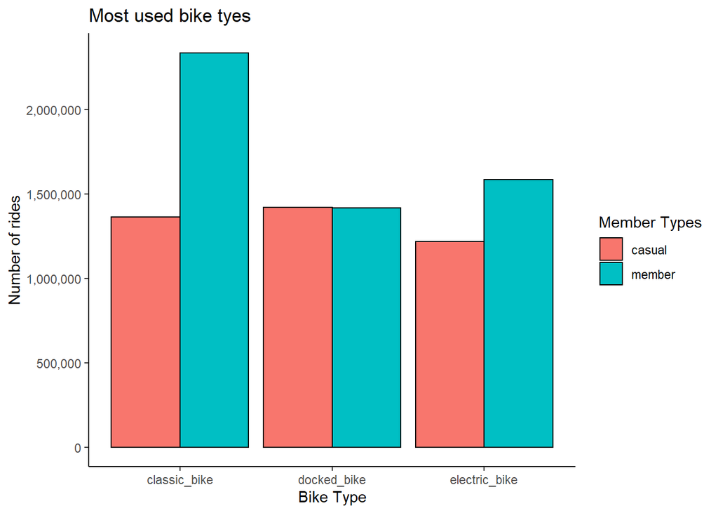

```r
# Plot it

ggplot(bike_plot, aes(x = rideable_type, y = number_of_rides, fill = member_type)) +
  geom_col(position = "dodge",color="black") +
  theme(panel.border = element_blank(),
        panel.grid.major = element_blank(),
        panel.grid.minor = element_blank(),
        axis.line = element_line(colour = "black")
  ) +
  theme_classic() +
   scale_y_continuous(labels = scales::comma) +
  labs(
    title="Most used bike tyes",
    x = "Bike Type",
    y = "Number of rides",
    fill='Member Types'
  )
```

We can see from the data that casual users use all 3 types of bikes pretty equally while the annual members have a preference for the classic bikes.

Now let’s look at the station data

As explained before, there are quite a lot of stations with blank names so we will have to drop these columns for now. Ideally we would ask the Cyclist team for more information as to why these are missing but for the purpose of this exercise we will drop them

```r
# So let's create 2 new datasets; one without the blank start_station_names and one without the blank end_station_names

merged_df_stations_start <- with(merged_df_clean_v2, merged_df_clean_v2[!(start_station_name == "" | is.na(start_station_name)), ])

merged_df_stations_end <- with(merged_df_clean_v2, merged_df_clean_v2[!(end_station_name == "" | is.na(end_station_name)), ])
```

```r
# Now let's create the handy dataframe for our stations plots


start_station_plot <- merged_df_stations_start %>%
  group_by(start_station_name, member_type) %>%
  summarize (number_of_rides = n()) %>%
  arrange(-number_of_rides) %>%
  head(10)
end_station_plot <- merged_df_stations_end %>%
  group_by(end_station_name, member_type) %>%
  summarize (number_of_rides = n()) %>%
  arrange(-number_of_rides) %>%
  head(10)
```

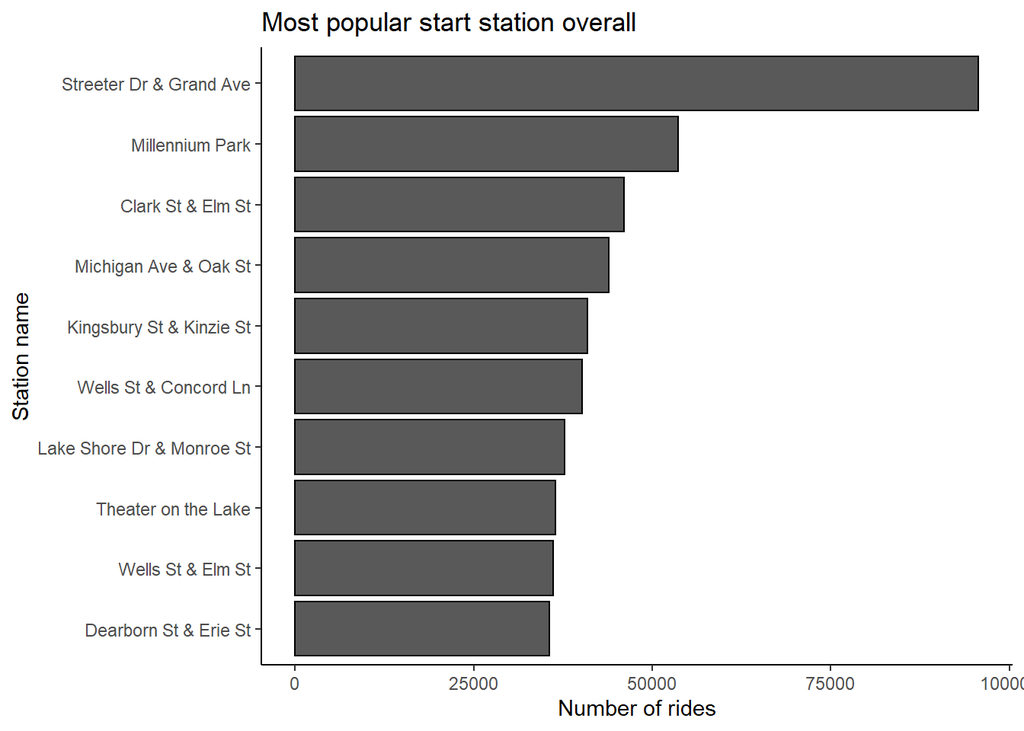

```r
# Now let's find out the most popular start station overall

ggplot(start_station_plot, aes(x = number_of_rides , y =reorder(start_station_name, number_of_rides))) +
  geom_col(color="black") +
  theme(panel.border = element_blank(),
        panel.grid.major = element_blank(),
        panel.grid.minor = element_blank(),
        axis.line = element_line(colour = "black")
  ) +
  theme_classic() +
  labs(
    title="Most popular start station overall",
    x = "Number of rides",
    y = "Station name",
  )
```

Looks like Streeter Dr and Grave Ave is by far the most popular station with Millenium Park and Clark St & Elm St coming after

Now let’s divide this by members and casuals and see what stations they prefer

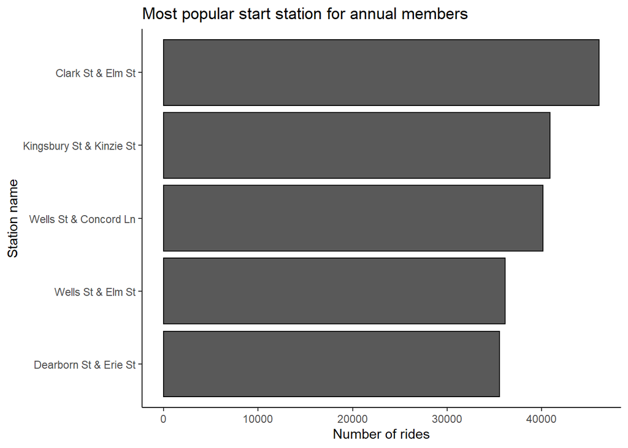

```r
# Start by the annual members

start_station_plot %>%
  filter(member_type == "member") %>%
  ggplot(aes(x = number_of_rides , y =reorder(start_station_name, number_of_rides))) +
  geom_col(color="black") +
  theme(panel.border = element_blank(),
        panel.grid.major = element_blank(),
        panel.grid.minor = element_blank(),
        axis.line = element_line(colour = "black")
  ) +
  theme_classic() +
  labs(
    title="Most popular start station for annual members",
    x = "Number of rides",
    y = "Station name",
  )
```

So it seems like the most popular overall stations are not actually very popular with the annual members

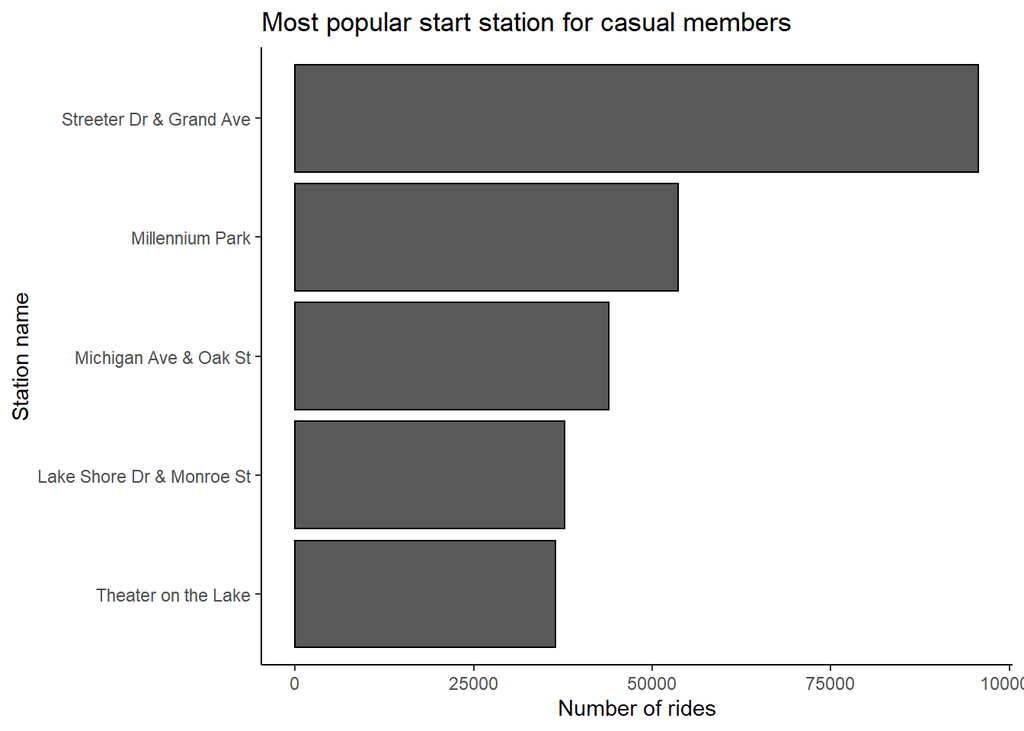

```r
start_station_plot %>%
  filter(member_type == "casual") %>%
  ggplot(aes(x = number_of_rides , y =reorder(start_station_name, number_of_rides))) +
  geom_col(color="black") +
  theme(panel.border = element_blank(),
        panel.grid.major = element_blank(),
        panel.grid.minor = element_blank(),
        axis.line = element_line(colour = "black")
  ) +
  theme_classic() +
  labs(
    title="Most popular start station for casual members",
    x = "Number of rides",
    y = "Station name",
  )
```

The casual members are overwhelmingly starting their rides at Streeter Dr & Grand Avenue with Millennium Park coming in second. Interesting to see there is no station that shows up in both graphs so it seems like in this metric the casuals and members completely differ.

Now let’s look at the routes

```r
# Make a new dataframe with all the blank routes dropped

merged_df_route <- with(merged_df_clean_v2, merged_df_clean_v2[!(route == "--" | is.na(route)), ])

# Make a handy dataframe to plot with

route_plot <- merged_df_route %>%
  group_by(route, member_type) %>%
  summarize (number_of_rides = n()) %>%
  arrange(-number_of_rides) %>%
  head(10)
head(route_plot)
```

```
# A tibble: 6 × 3
# Groups:   route [6]
  route                                              member_type number_of_rides
  <chr>                                              <chr>                 <int>
1 Streeter Dr & Grand Ave -- Streeter Dr & Grand Ave casual                17793
2 Millennium Park -- Millennium Park                 casual                10850
3 Lake Shore Dr & Monroe St -- Lake Shore Dr & Monr… casual                 9736
4 Michigan Ave & Oak St -- Michigan Ave & Oak St     casual                 9306
5 Buckingham Fountain -- Buckingham Fountain         casual                 8052
6 Indiana Ave & Roosevelt Rd -- Indiana Ave & Roose… casual                 6533
```

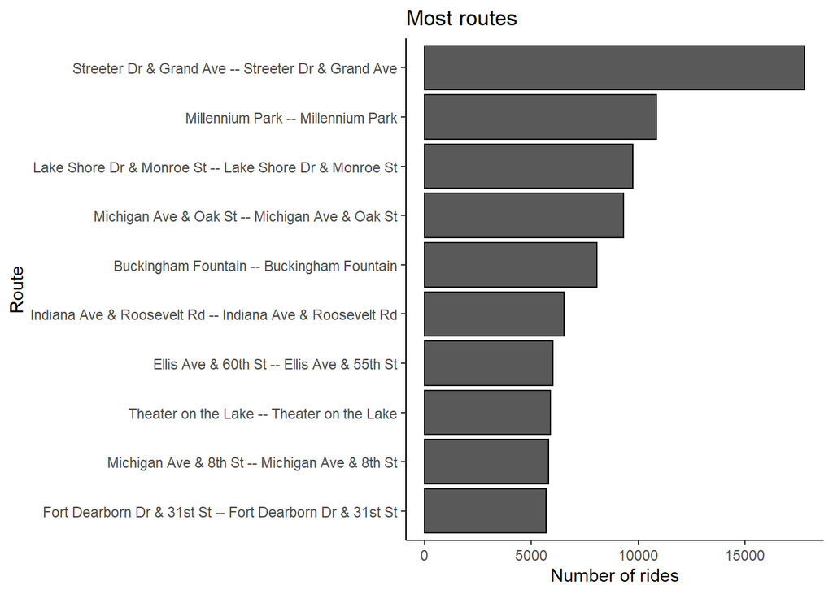

```r
  ggplot(route_plot, aes(x = number_of_rides , y =reorder(route, number_of_rides))) +
  geom_col(color="black") +
  theme(panel.border = element_blank(),
        panel.grid.major = element_blank(),
        panel.grid.minor = element_blank(),
        axis.line = element_line(colour = "black")
  ) +
  theme_classic() +
  labs(
    title="Most routes",
    x = "Number of rides",
    y = "Route",
  )
```

The interesting takeaway here is that the 9 of the 10 most popular routes all end in the same station they started.

# *—-FINDINGS—-*

# *—-ACT—-*

There are 2 ways we could think about acting. The first is to look at what is already working and the trends shown above and use that to make it even more attractive for the casuals to convert to annual members. For this approach we could perhaps add another member tier where the customer pays less and gets discounts on rides during the weekends. Another way is to allow annual members to be able to select their “main” station and rides from those stations will cost less than normal rides. Since casual riders use the bikes for longer perhaps you could also give annual members a progressive discount that becomes bigger the more you ride the bikes.

The second way of acting would involve looking at the current weaknesses and trying to improve those in order to make it more attractive for casuals to make the switch. For this approach we would look at the fact that the casual ridership during the weekdays is much lower so perhaps if we could make it more attractive to ride during the weekdays we could convince casuals to start using the service in those days as well encouraging them to eventually make a switch. We can also see that the casuals use the service much less during the morning hours so perhaps making it more attractive to use the service in those hours can eventually convince casuals to use the service more and make the switch.

Personally, I would go with the first approach as the second is very risky and we need some more data such as perhaps the occupation, gender and age of the riders as well as a survey to know a bit better what the casuals actually think about the service and if they are even able to use it more during weekdays and etc.

# *—PERSONAL OPINIONS—-*

I had a lot of fun creating this project and it was very interesting to learn more about R and it’s uses. Overall, I found it a very responsive language and I love how easy it is to plot graphs and clean data. I look forward to using it more in the future and will definitely try some other projects with it.

Most of the issues I encountered were actually with my PC since this dataset is a very large one and sometimes it would reach a bottleneck making me have to restart R. Also, since it was my first project with this language, I naturally had a few difficulties in finding out exactly what commands I have to use and how to do certain things. Thankfully there is a lot of documentation out there as well as many communities such as Kaggle with other users and notebooks that explain and can serve as inspiration in how to best use this amazing programming language.